# Species interactions and thermal constraints on ant community structure - Wittman - 2010 - Oikos - Wiley Online Library

Access ByCzechs- Biological Institution Of Cas

[Oikos](https://onlinelibrary.wiley.com/journal/16000706)

[Volume 119, Issue 3](https://onlinelibrary.wiley.com/toc/16000706/2010/119/3)

Full Access

# Species interactions and thermal constraints on ant community structure

[Sarah E. Wittman](https://onlinelibrary.wiley.com/action/doSearch?ContribAuthorStored=Wittman%2C+Sarah+E)

[Nathan J. Sanders](https://onlinelibrary.wiley.com/action/doSearch?ContribAuthorStored=Sanders%2C+Nathan+J)

[Aaron M. Ellison](https://onlinelibrary.wiley.com/action/doSearch?ContribAuthorStored=Ellison%2C+Aaron+M)

[Erik S. Jules](https://onlinelibrary.wiley.com/action/doSearch?ContribAuthorStored=Jules%2C+Erik+S)

[Jaime S. Ratchford](https://onlinelibrary.wiley.com/action/doSearch?ContribAuthorStored=Ratchford%2C+Jaime+S)

[Nicholas J. Gotelli](https://onlinelibrary.wiley.com/action/doSearch?ContribAuthorStored=Gotelli%2C+Nicholas+J)

First published: 13 April 2010

https://doi.org/10.1111/j.1600-0706.2009.17792.x

Citations: 45

S. E. Wittman, Dept of Biology, Univ. of Vermont, Burlington, VT 05405, USA. E‐mail: sarah.wittman@uvm.edu

## Abstract

Patterns of species occurrence and abundance are influenced by abiotic factors and biotic interactions, but these factors are difficult to disentangle without experimental manipulations. In this study, we used observational and experimental approaches to investigate the role of temperature and interspecific competition in controlling the structure of ground‐foraging ant communities in forests of the Siskiyou Mountains of southwestern Oregon. To assess the potential role of competition, we first used null model analyses to ask whether species partition temporal and/or spatial environments. To understand how thermal tolerances influence the structure of communities, we conducted a laboratory experiment to estimate the maximum thermal tolerance of workers and a field experiment in which we added shaded microhabitats and monitored the response of foragers. Finally, to evaluate the roles of temperature and interspecific competition in the field, we simultaneously manipulated shading and the presence of a dominant competitor (*Formica moki*). The foraging activity of species broadly overlapped during the diurnal range of temperatures. Species co‐occurrence patterns varied across the diurnal temperature range: species were spatially segregated at bait stations at low temperatures, but co‐occurred randomly at high temperatures. The decreased abundance of the co‐occurring thermophilic *Temnothorax nevadensis* in shaded plots was a direct effect of shading and not an indirect effect of competitive interactions. Thermal tolerance predicted the response of ant species to the shading experiment: species with the lowest tolerances to high temperatures showed the greatest increase in abundance in the shaded plots. Moreover, species with more similar thermal tolerance values segregated more frequently on baits than did species that differed in their thermal tolerances. Collectively, our results suggest that thermal tolerances of ants may mediate competitive effects in habitats that experience strong diurnal temperature fluctuations.

A major goal of ecology is to identify the processes that control patterns of community structure. At large spatial scales, historical processes determine properties of the regional species pool (Ricklefs 2004), which in turn influence the composition of local communities (Webb et al. 2002, Wiens and Donoghue 2004). At smaller spatial scales, both abiotic filtering (pH, temperature, water availability, etc.), and biotic interactions (interspecific competition, parasites, herbivory, etc.) may operate to determine which species occur, and co‐occur, together within the local community (Weiher and Keddy 1999, Cavender‐Bares et al. 2009).

Within local communities, theory predicts either separation or aggregation of important ecological traits among closely related species, depending on the relative role of biotic interactions versus the abiotic environment, respectively, on community membership. Closely related species occurring in the same habitat often have similar requirements and share similar ecological traits. Thus, classical niche theory of limiting similarity (Hutchinson 1959, MacArthur and Levins 1967) predicts that species with similar traits cannot coexist due to competition for limiting resources. Competitive exclusion may occur between species sharing similar ecological traits, resulting in segregation of species with similar traits (Winston 1995). On the other hand, if tolerance to abiotic conditions is more important than biotic interactions, then species can only occur if they possess specific ecological traits. When environmental conditions primarily determine community membership, we expect to find positive associations of species with similar traits across sites (Jackson et al. 1992).

Ants are an ideal taxon with which to study the relative influence of biotic and abiotic environment, as there is good evidence that both interspecific competition (reviewed by Hölldobler and Wilson 1990) and thermal constraints on foraging activity and colony performance (Bestelmeyer 1997, Cerdá et al. 1998, Holway et al. 2002) control ant community structure. Ant responses to temperature and competition have been used to describe dominance–diversity patterns on continental scales (Andersen 1992, Parr et al. 2005), responses to disturbance (Andersen 1991, York 2000, Farji‐Brener et al. 2002), and the invasion success of non‐native species (Holway et al. 2002).

In this study, we first measured statistical patterns of ant species co‐occurrence and activity at food resources. We then measured the thermal tolerance of the eight most common ant species in a laboratory experiment. Finally, we added shade and removed a dominant ant competitor in a controlled field experiment to understand how thermal tolerance and inter‐specific competition shape ant communities. Specifically, we asked: (1) is there statistical evidence that species partition their temporal or spatial environment over a range of temperatures? (2) Does physiological thermal tolerance predict how species respond to changes in their thermal environment? (3) Are species with more similar thermal tolerance traits more or less likely to co‐occur within sites? (4) Do temperature and the presence of a behaviorally dominant species interact to affect the foraging activity of a subordinate species?

## Methods

### Study area

This research was conducted in the Siskiyou Mountains of southwestern Oregon and northern California, USA, during the summers of 2003–2005. This area is part of the Klamath‐Siskiyou ecoregion that has a Mediterranean climate with cool winters (mean January minimum temperature = 0°C) and warm dry summers (mean July maximum temperature = 31.7°C; mean annual precipitation = 154 cm, with only 4 cm falling between June and August). During the summer months there is a large diurnal variation in temperature (soil surface temperature range of 10–75°C), but relatively little monthly variation (mean monthly temperatures of June, July, August between 21.1 and 26.6°C). Forests are mostly open stands of *Pinus jeffreyi*; other sclerophyllous trees are reduced to a shrub layer (Whittaker 1960).

### Temporal and spatial partitioning

We first assessed whether species partitioned their temporal or spatial environments. We used null model analysis of patterns of species occurrence and worker abundance throughout day across 16 environmentally homogeneous, representative forest sites. During the summer of 2003, we sampled the ant community by establishing in each site an 8 × 8 m sampling grid of 25 bait stations arranged in a 5 × 5 grid with 2‐m spacing. Each bait station consisted of two laminated 7.6 × 12.7 cm index cards, one baited with ∼5.5 g of tuna and the other with a 6280 mm<sup>3</sup> volume cotton ball soaked in honey water. Each bait station was censused a total of nine times (three observations in each of three time blocks). Time blocks began at 08:30, 13:00 and 18:30 h, and the three observations within each time block were separated by 30 min (i.e. 08:30, 0:900, 09:30).

Species occurrences at baits may be dominated by behaviorally aggressive or mass‐recruiting species, so that baits can potentially under‐sample trophic specialists, solitary foragers and behaviorally subordinate species. We used several baits in each site and made multiple observations throughout the day to minimize these potential omissions (Bestelmeyer et al. 2000). We supplemented the bait‐station data by visually searching the plots during all 9 sampling periods, but only one ant species that did not occur at baits, *Lasius flavus*, was found by visual searching. Thus, we are confident that our sampling strategy captured the potential changes in the activity of foraging ants over the course of the day and adequately sampled the community.

During each of the nine sampling periods, we observed each bait station for approximately 20 s, recorded the number and identity of each species present, and estimated the soil surface temperature to the nearest 0.1°C using a handheld infrared thermometer. Individual workers were collected at the end of a time block if they could not be readily identified in the field. Phil Ward at the Univ. of California, Davis confirmed the species identifications. Voucher specimens are deposited at the Univ. of Tennessee in Knoxville. Nomenclature follows Bolton (2003).

### BACI shading experiment

During June–August, 2004, we conducted a shading experiment at a single site (SE) within the sampling area of the 2003 census (42.49°N, 123.78°W, elevation 430 m.a.s.l.). Rank abundances and behavioral profiles of ants at the shading experiment site were similar to those of ants sampled at other sites in the region in 2003 (Witt‐man 2007). Fifteen pairs of shade and no shade (=control) blocks were established throughout the site in a randomized block design. Each block was located in a relatively homogenous environment, and treatments were randomly assigned to plots within the block. Within a block, two treatment areas of 0.5 × 0.5 m were delineated with four 25‐cm metal stakes driven into the ground on each of the four corners. Control plots received no further manipulation. Shade plots were covered with heavy‐duty brown industrial polyethylene tarps that were taped to the four stakes at a height of 15 cm above the substrate. Treatments within each block were separated by 5 m, and blocks were separated by 15 to 25 m.

Less than 20% of the shaded plots contained nest entrances (of those shade additions covering nest entrances, about half belonged to *Temnothorax nevadensis* and half to *Solenopsis molesta*). Moreover, we followed foragers from baits back to nest entrances and found that nest entrance locations did not change during the duration of our experiment.

On sampling days, baits were set under control and shade stations at 07:30 and censused seven times throughout the day (three morning, one afternoon and three evening samples). Sampling periods began at 08:15, 14:30 and 18:15, and periods with multiple censuses were sampled every 45 min. Baits consisted of ∼5 g of tuna in oil placed on 7.6 × 12.7 cm laminated index cards. At each census, we recorded the number and identity of each species and estimated the soil surface temperature under and around each bait station to the nearest 0.1°C hand‐held infrared thermometer.

To assess competitive ability of each species, we quantified species interactions and behavioral dominance at the control baits. Pairwise interactions between workers of two different species were categorized as ‘attacks’ or ‘avoidances’ (Fellers 1987). An attack consisted of active participation of at least two workers in which one individual bit, chased, lunged, or used chemical spray to cause the other individual to retreat. Occasionally an attack would result in a severe injury or death. Avoidance behavior occurred when workers of one species retreated from the bait card after making contact with another in the absence of an obvious attack. A species was characterized as dominant if it attacked or if its presence elicited avoidance behavior in individuals of another species. Using the method of Fellers (1987), the dominance index for each species was defined as the percentage of times it was dominant during all instances of its attacks and avoidances (Table 1). Note that some dominance indices are based on only one observation; however, the general pattern of dominance and bait occurrence displayed in Table 1 is consistent with behavioral and occurrence data collected at 16 other sites in the region (Wittman 2007).

Table 1. Species list and summary results of behavioral observations at baits at the SE site. Entries display the total number interactions with other species, the number of dominant behaviors exhibited during those interactions, percentage of interactions in which a species was dominant (= dominance index, sensu Fellers 1987), the number of species with which each species interacted (max = 7), and the number of bait stations each species visited (max = 30).

| Species | Total no. interactions | No. dominant interactions | Dominance index | No. species interacted | No. bait stations |
| --- | --- | --- | --- | --- | --- |
| *Formica moki* (Fm) | 18 | 12 | 67 | 6 | 14 |
| *Temnothorax nevadensis* (Tn) | 14 | 2 | 14 | 4 | 26 |
| *Tapinoma sessile* (Ts) | 5 | 0 | 0 | 2 | 10 |
| *Aphaenogaster occidentalis* (Ao) | 5 | 3 | 60 | 3 | 5 |
| *Crematogaster coarctata* (Cc) | 5 | 5 | 100 | 2 | 4 |
| *Solenopis molesta* (Sm) | 3 | 2 | 67 | 1 | 9 |
| *Camponotus vicinus* (Cv) | 1 | 1 | 100 | 1 | 2 |
| *Liometopum luctuosum* (Ll) | 1 | 1 | 100 | 1 | 4 |

### Thermal tolerance experiment

We measured thermal tolerance of all eight species observed during the BACI shading experiment (species listed in Table 1). We collected workers of each species from nest entrances and vegetation that was well beyond the area of the shading experiment. Within four hours of field collection, individual workers were exposed to slowly increasing temperatures in a heat block. Eight workers of each species were placed into individual 1.5‐ml micro‐centrifuge tubes and randomly assigned to a well within the heat block. Temperature exposure began at 40°C and was increased in 2° intervals to 50°C. Individuals were exposed to each temperature for 10 min, and the temperature was recorded when individuals died or permanently lost muscle coordination. Each species trial was replicated six times. The mean temperature of death for the eight individual workers was calculated as an index of thermal tolerance for each species.

### Shading and species removal experiment

We denied *F. moki* workers access to removal treatments by installing temporary fencing and setting temporary ‘distraction’ baits close to the nest entrance(s) to lure *F. moki* workers away from the removal plots. Once treatments were in place, we sampled for a total of 7 days; each sampling day was separated by 2–3 days. Baits were set at 07:30 and we sampled stations every hour from 08:00 until 11:00. Data from one removal plot was not included in the analysis because we were not able to successfully remove *F. moki*. Data from two control stations were also excluded because foragers in these plots were affected by the ‘distraction’ baits used in the removal experiment.

### Analyses

#### Temporal overlap and spatial partitioning

#### Temporal niche overlap

To determine whether species segregate or aggregate their activity over the diurnal timeframe, we used null model analyses to examine the temporal overlap of species at each of the 16 plots sampled in 2003. Matrices were constructed with species (n = 5 to 12 species) as rows and time of day (n = 9) as columns for each plot. Matrix entries were the number of baits (max = 25) occupied by each species at each observation period in each plot.

The average pairwise niche overlap was then compared to the average calculated for randomized assemblages. Communities were randomized 1000 times using randomization algorithm 2 (RA2) of the niche overlap model in EcoSim, ver. 7 (Gotelli and Entsminger 2006). RA2 retains zero states: if a species never occurred naturally during a specific time period, it would not in the randomized assemblage either (Winemiller and Pianka 1990). RA2 also relaxes niche breadths, substituting a random uniform number for bait occupancy throughout the day. This algorithm is recommended when certain resource states are unavailable for some species (e.g. when physiological constraints prevent activity during hot times of the day) but there are no other constraints on resource use (Gotelli and Entsminger 2006). Resource states were set as equiprobable, as time is assumed to be equally ‘available’ to all species in the absence of species interactions. If species are partitioning the time of day in which they are active, then the niche overlap index should be smaller than expected by chance (i.e. smaller than the indices generated from the null assemblages).

#### Spatial partitioning

To determine whether species co‐occurrence patterns were segregated or aggregated in space, we analyzed species cooccurrence patterns at baits within each of the 16 forested sites. Furthermore, to determine whether the spatial pattern of co‐occurrence varied among diurnal times and temperatures, we analyzed species occurrence patterns during one sampling period in the morning, afternoon, and evening. Presence–absence matrices were constructed with species (n = 1 to 9) as rows and bait locations (n = 25) as columns. A total of 48 (3 times of day × 16 replicates) matrices were evaluated.

We used the C‐score of Stone and Roberts (1990) to evaluate species co‐occurrence patterns. This score measures the average number of ‘checkerboard units’ of all species pairs of an assemblage. Each checkerboard unit is calculated by (r<sub>a</sub>− S)(r<sub>b</sub>− S) where S is the total number of ‘sites’ (e.g. bait locations) shared by the species pair, and r<sub>a</sub> and r<sub>b</sub> are the row totals for species a and b, respectively. Species that always occur together (complete aggregation) will have a C‐score of zero. The greater the segregation in species, the larger the C‐score will be. Observed C‐scores were compared to average C‐scores generated from 5000 randomized matrices. Null assemblages were created in EcoSim using a fixed‐equiprobable model (SIM2), an algorithm robust to both type I and type II error (Gotelli 2000). In this model, row totals (= number of baits a species occupies) are held constant and the 25 bait stations are treated as equally suitable for species occupation. Differences in the standard effect size (SES) were compared among times of day with a one‐way analysis of variance (ANOVA). The SES reports the number of standard deviations the observed index is above or below the mean of the randomized assemblage to allow comparison among multiple tests (Gurevitch et al. 1992). It is calculated as (I<sub>obs</sub>−I<sub>sim</sub>)/S<sub>sim</sub>, where I<sub>obs</sub> corresponds to the index for the observed assemblage, I<sub>sim</sub> corresponds to the index for the null assemblages, and S<sub>sim</sub> is the standard deviation of the null assemblages. Assuming a normal distribution of deviations, approximately 95% of the SES values should fall between −1.96 and 1.96. Values larger than 1.96 indicate non‐random species segregation, and values lower than −1.96 indicate non‐random species aggregation.

#### BACI shading experiment

Differences in abundance between shade and control groups were evaluated with a randomized block ANOVA. Shade was considered to be a fixed effect, and analyses were run separately for each week, i.e. during times when all stations were unshaded (week I–II) and during times when half of the stations were shaded (week III–V). We estimated abundance as both bait occurrence and abundance. Bait occurrence values were defined as the number of baits visited by different species, regardless of the number of workers present. Abundance was defined as the total number of workers recorded at baits, and was log transformed to meet assumptions of ANOVA. We analyzed the abundance of all species combined as well for the abundance of T. nevadensis, the only species common enough to analyze separately.

#### Thermal tolerance experiment

We evaluated differences in thermal tolerances among species with a one‐way ANOVA, and compared individual species’ responses with Tukey's honest significant difference (HSD) test. We also determined whether laboratory‐determined thermal tolerance values were representative of foraging behavior observed in the field. Using each species as an observation, we regressed thermal tolerance against the observed temperature of maximum foraging activity of each species. A positive relationship with a slope = 1 would suggest perfect correlation between thermal tolerance and foraging activity.

To determine whether thermal tolerance predicts how species respond to shade additions, we first quantified the change in abundance of each species after application of shade tarps as the average percent change in worker numbers in the treatment plots from the unshaded period (week I–II) to the shaded period (week III–V). To ensure effects of shade treatments we not confounded with any unmeasured variable that varied through time, we also calculated the change in abundance of all species in the control plots through time (= average percent change in abundance of control plots from week I–II to week III–V). Using each species as an observation, we regressed the change in abundance after shade application (treatments) and through time (control) against thermal tolerance. We used a randomization test implanted in EcoSim (Gotelli and Entsminger 2006) to test for the statistical significance of the slope.

To test whether species with similar traits were more likely or less likely to co‐occur, we paired the thermal tolerance results with analyses of species co‐occurrence. We quantified co‐occurrence patterns of each species pair at the SE site. Matrices consisted of two rows (= species) and 15 columns (= baits). A species was considered ‘present’ if it occurred at the baits at any sampling period during the initial, unshaded portion. We used the same null model parameters as in the previous co‐occurrence analysis. Using each species pair as an observation, we regressed the absolute difference in thermal tolerance against the SES values from the co‐occurrence analyses. If species with more similar traits co‐occur more often than expected by chance (large negative SES values), then we expect a positive relationship between similarity in thermal traits and SES values. If species with more similar traits co‐occur less often than expected by chance (large positive SES values), then we expect a negative relationship between similarity in thermal traits and SES values.

#### Shading and species removal experiment

We performed a two‐way ANOVA with shade and removal of *F. moki* as fixed effects on the abundance of *F. moki* and *T. nevadensis*. Abundance values were log‐transformed to meet assumptions of ANOVA. We used a two‐factor, factorial, nominal, logistic model to investigate the effects of *F. moki* removal and shade addition on the bait occupancy of all other species observed. Analyses were run separately on each of the four sampling periods (= times of day). These analyses were conducted in JMP, ver. 4.0.2 (SAS Inst.).

## Results

### Community composition

In 2003, we observed in the forested habitat a total of 34942 ants from 24 species and 11 genera at 16 sites (Ratchford et al. 2005). Mean local richness per site was usually approximately eight species (range = 5 to 12). *Aphaenogaster occidentalis*, *Camponotus vicinus*, *Tapinoma sessile* and *Temnothorax nevadensis* occurred at the majority of sites and collectively constituted between 29% and 86% of the species occurrences observed at bait stations within a site. Less regionally‐widespread species that were locally numerically dominant included *Crematogaster coarctata*, *Formica subelongata* and *F. moki*. *Camponotus essigi, C. laevigatus, Formica neogagates, F. accreta, Liometopum occidentale* and *Solenopsis molesta* were rare and were observed only at one site. At the experimental study site, eight species were collected, and the numerically dominant species were *F. moki*, *Ta. sessile* and *Te. nevadensis*.

### Site characteristics

Temperature did not vary widely among baits within sites during a sampling period (average coefficient of variation among sites = 0.160; range = 0.027 to 0.328). Average temperature during morning, afternoon, and evening time blocks did not vary among sites (F<sub>15,47</sub>= 0.452, p = 0.948). Soil surface temperature varied significantly throughout the day (F<sub>2,47</sub>= 50.336, p < 0.001) with hot afternoon temperatures (mean afternoon temperature °C ± 1 SE = 49.16 ± 1.67) higher than either morning (30.02 ± 1.36) or evening (26.37 ± 1.36) temperatures (Tukey's HSD test, p < 0.05).

### Temporal and spatial partitioning

#### Temporal niche overlap

The temporal niche overlap index was larger than expected by chance in 13 of the 16 sites (p<sub>obs</sub> > p<sub>exp</sub>; p < 0.05), indicating that species broadly aggregated their activities throughout the day.

#### Spatial partitioning

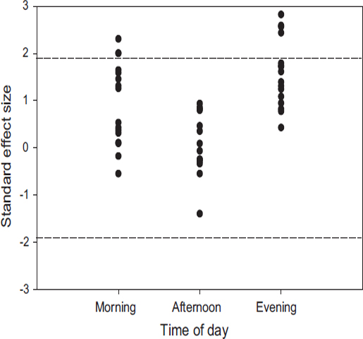

**Figure 1**

Open in figure viewer[PowerPoint](https://onlinelibrary.wiley.com/action/downloadFigures?id=f1&doi=10.1111%2Fj.1600-0706.2009.17792.x)

Co‐occurrence values for ant communities at three temporal snapshots. Points represent sites’ standard effect scores (SES) across the three sample periods. Sites with SES values greater than 1.96 indicate significant species segregation, and SES values less than ‐1.96 indicate significant species aggregation.

### BACI shading experiment

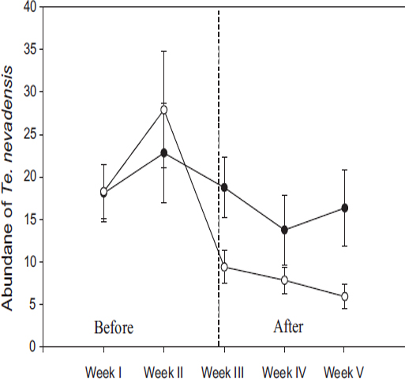

**Figure 2**

Open in figure viewer[PowerPoint](https://onlinelibrary.wiley.com/action/downloadFigures?id=f2&doi=10.1111%2Fj.1600-0706.2009.17792.x)

### Thermal tolerance experiment

The average maximum temperature tolerances ranged from 44.0 to 48.1°C (Fig. 3). *Aphaenogaster occidentalis* was the least thermally tolerant species and *T. nevadensis*, *C. coarctata* and *Liometopum luctuosum* were the most thermally tolerant (Fig. 3). Thermal tolerance measured in the laboratory was marginally associated with maximum foraging temperatures observed in the field (observed r = 0.524, mean of simulated =−0.025, p = 0.073).

[figure not shown]

**Figure 3**

Open in figure viewer[PowerPoint](https://onlinelibrary.wiley.com/action/downloadFigures?id=f3&doi=10.1111%2Fj.1600-0706.2009.17792.x)

Mean death temperature of all species observed during the BACI shading experiment. Thermal tolerances of species under the same horizontal line were not significantly different from each other (Tukey's HSD test). Species abbreviations as in Table 1.

Thermal tolerances of species predicted changes in abundance in shaded plots (observed slope =−8.371, mean of simulated slopes =−0.220, p = 0.007; Fig. 4). Species with low thermal tolerances increased in abundance in shaded plots relatively more than did species with high thermal tolerance. Thermal tolerance was not associated with natural changes in abundance over time as measured in the control plots (observed slope =−3.746, mean of simulated slopes =−0.040, p = 0.138).

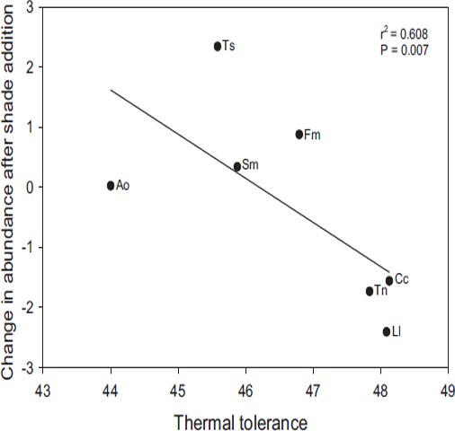

**Figure 4**

Open in figure viewer[PowerPoint](https://onlinelibrary.wiley.com/action/downloadFigures?id=f4&doi=10.1111%2Fj.1600-0706.2009.17792.x)

Thermal tolerance values predict percent changes in abundance after the addition of shade (observed slope =−8.371, mean of simulated slopes =−0.220, p = 0.007). Points represent individual species (see Table 1 for species abbreviations).

Similarity of thermal traits predicted patterns of cooccurrence among species pairs (observed slope =−0.3155, mean of simulated slopes =−0.0004, p = 0.042; Fig. 5). Species pairs with similar thermal tolerances were more likely to be spatially segregated (large positive SES values) within the SE site.

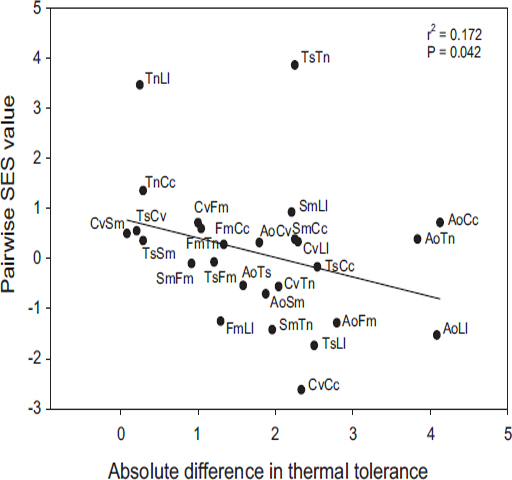

**Figure 5**

Open in figure viewer[PowerPoint](https://onlinelibrary.wiley.com/action/downloadFigures?id=f5&doi=10.1111%2Fj.1600-0706.2009.17792.x)

Relationship between similarity in thermal tolerance and patterns of co‐occurrence between all species observed at one local site. Points represent unique species pairs; see Table 1 for species abbreviations. Similarity in thermal tolerance was calculated as the absolute difference in laboratory measured thermal tolerance values. Co‐occurrence patterns were determined from field observations at baits and are expressed as standard effect sizes (SES). SES values greater than 1.96 indicate significant species segregation, and SES values less than −1.96 indicate significant species aggregation. Species pairs with similar thermal tolerances were more likely to be spatially segregated (observed slope =−0.3155, mean of simulated slops =−0.0004, p = 0.042).

### Shade and removal experiment

Removal of *F. moki* increased the likelihood of bait occupancy by two of the seven other ant species: *T. nevadensis* occupied more baits in the removal treatment during three sampling periods (= times of day), and *T. sessile* occupied more baits in the removal treatment during two sampling periods (Table 2). Shading increased the likelihood that *A. occidentalis* occupied baits during two sampling periods but decreased the likelihood that. *Temnothorax nevadensis* occupied baits (Table 2). Shade and removal treatments had no effect on bait occupancy by *S. molesta*.

Table 2. Results of nominal logistic analysis of the effects of shading and *F. moki* removal on bait occurrence data collected during four separate sampling periods (08:00–11:00). Analyses were run separately for each species. *Crematogaster coarctata* and *L. luctuosum* did not occur at sufficient baits for the analysis. Cells boxed with a solid line indicate a greater chance of bait occupancy, while cells boxed with a dashed line indicate a reduced chance of bait occupancy. No interactions between shading and removal treatments were found were found (p > 0.05). Species abbreviations as in Table 1.

| Species | 8:00 Removal | 8:00 Shade | 9:00 Removal | 9:00 Shade | 10:00 Removal | 10:00 Shade | 11:00 Removal | 11:00 Shade |
| --- | --- | --- | --- | --- | --- | --- | --- | --- |
| Ao | 0.162 | 0.046 | 0.167 | 0.004 | 1.000 | 1.000 | 0.958 | 0.945 |
| Cc | . | . | . | . | . | . | . | . |
| Fm | 0.570 | 0.767 | 0.002 | 1.000 | 0.047 | 0.999 | <0.001 | 0.063 |
| Ll | . | . | . | . | . | . | . | . |
| Sm | 0.328 | 0.328 | 0.098 | 1.000 | 0.098 | 1.000 | 0.345 | 0.262 |
| Tn | 0.307 | 0.019 | 0.034 | 0.034 | 0.046 | 0.162 | 0.014 | 0.932 |
| Ts | 0.047 | 0.999 | 0.887 | 0.887 | 0.047 | 0.999 | 0.098 | 1.000 |

## Discussion

In the Siskiyou Mountains, community organization and foraging abundance of ants at the local scale appears to be controlled primarily by the thermal environment, and secondarily by biotic interactions. Species aggregate foraging activity across the diurnal timeframe , with activity levels dropping in the hottest part of the day and increasing during cooler hours (Wittman 2007). In our study area, diurnal temperature fluctuates widely, likely setting hard boundaries to activity levels. Temperature is a cue for ants to leave the nest to forage (Muser et al. 2005, Azcarate et al. 2007), and ants generally forage within a limited thermal range (Garcia‐Perez et al. 1994, Cerdà et al. 1997, Pol and de Casenave 2004). Humidity may also interact with temperature to form a ‘temperature‐humidity envelope’ (Hölldobler and Wilson 1990) that dictates when workers can be active (Talbot 1946, Kuate et al. 2008).

Our study provides evidence that physiological thermal tolerance predicts how ant species respond to changes in their thermal environment: the less thermally tolerant a species was, the greater was its change in abundance after shade additions (Fig. 4). Due to the short duration of the shading experiment, the abundance changes we documented likely are not measures of change in population size of ant colonies, but rather measures of changes in foraging behavior at baits. Because abundance was quantified as the sum of workers observed throughout the day, if a species increased recruitment or total time spent foraging at a bait, it would be recorded as an overall increase in abundance. Thus, we conclude that shading most greatly impacted the foraging behavior of species most physiologically restricted by temperature (Fig. 4).

That thermal tolerance predicted changes in foraging abundance to shade additions is striking, considering the relatively small differences in thermal tolerance (Fig. 3), the small size of shade tarps (0.25 m<sup>2</sup>), which rarely covered nest entrances, and that physiologically driven responses were not drastically altered by any competitive interactions. Thermal control of forging activity is also very apparent in *T. nevadensis*, as evident in both the BACI shading experiment (Fig. 2) and the shading and removal experiment (Table 2, Fig. 6). Although its abundance increased in the removal experiment (Fig. 6), interactions between shading and *F. moki* removal were not statistically significant, suggesting additive effects of shading and competitors (Fig. 6).

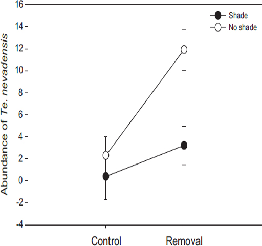

**Figure 6**

Open in figure viewer[PowerPoint](https://onlinelibrary.wiley.com/action/downloadFigures?id=f6&doi=10.1111%2Fj.1600-0706.2009.17792.x)

*Temnothorax nevadensis* worker numbers in the shade (dark markers) and no shade (light markers) treatments in areas where *F. moki* was removed and not removed. Adding shade decreased workers numbers on baits while removing *F. moki* increased *T. nevadensis* abundance. The interaction of shade and removal treatments was not significant (p = 0.290).

Temperature determined when species were generally active, setting the stage in which competitive interactions occurred. Co‐occurrence patterns differed during different times of day, with more segregation across baits during cooler times of day (Fig. 1). When fewer species were active in the hot afternoon, we found random co‐occurrence patterns. Our sites appeared structurally homogenous, we found little variation in temperature throughout a site, and interspecific aggression was conspicuous (Wittman 2007); thus, segregation likely resulted from competitive interactions rather than from responses to habitat or environmental heterogeneity. Competitive interactions also appear to be contingent upon temperature in other ant communities, and these interactions may vary with season (Retana and Cerdá 2000, Albrecht and Gotelli 2001) and habitat structure (Yanoviak and Kaspari 2000, Farji‐Brener et al. 2002, Gotelli and Ellison 2002). For example, Retana and Cerdá (2000) found competition is more prevalent in communities occurring in cooler habitats or during cooler seasons.

Thermal tolerance also influenced patterns of species co‐occurrence. Species pairs more similar in thermal tolerances showed greater segregation at baits (Fig. 5). These results make sense, given (1) the strong connection between thermal tolerance and the ability to forage in the thermal environment (Fig. 4); (2) that activity levels are broadly defined by temperature; and (3) that competitive interactions were more prevalent during times of greatest activity level (Fig. 1). Species with more similar thermal tolerance foraging during the same time were more likely to encounter competitors. Thus, we demonstrate how similarity in ecological traits defines the prevalence of competitive interactions (Johansson and Keddy 1991, Fig. 5) and that biotic interactions may change with abitoic conditions (Dunson and Travis 1991, Pennings 2003, Fig. 1).

Our results confirm the power of using a functional ecology approach (McGill et al. 2006) to bridge the gap of physiological and community ecology (Dunson and Travis 1991) and yield insights into how biotic and abiotic factors interact to determine spatial and temporal patterns of community structure. In the Siskiyou Mountains, communities assemble and disassemble along the thermally variable environment, and co‐occurrence patterns at the local appear to be determined, in part, by species thermal tolerance, a functional trait that strongly determines when a species can be active.

## Acknowledgements

We thank Nick Kaczmar, Rachel Lacy, Shannon McBride, Raynelle Rino and Patricia Wittman for help in the field, and the US Forest Service for access to sites. This work was supported by NSF grants 03‐01932, 03‐01361, 03‐01381 to NJS and ESJ, AME, and NJG, respectively.

## Citing Literature

back